# PEPE-USD

## PEPE-USD today is +0300, 2025-10-06, 00:24:58

This crypto forecast was generated by gemini-2.0-flash API

## Daily Chart

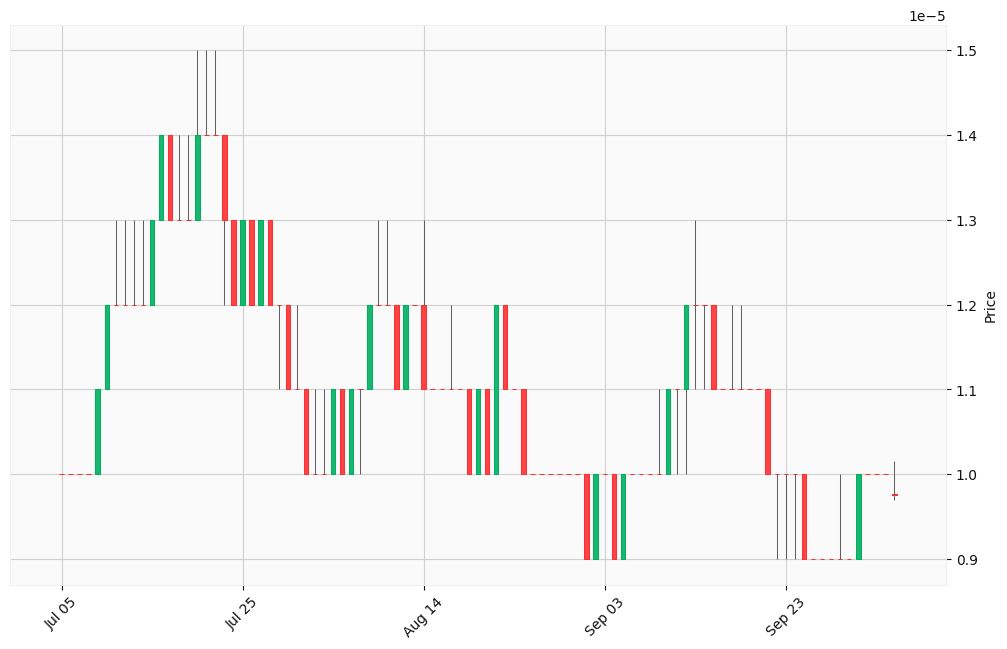

## Hourly Chart

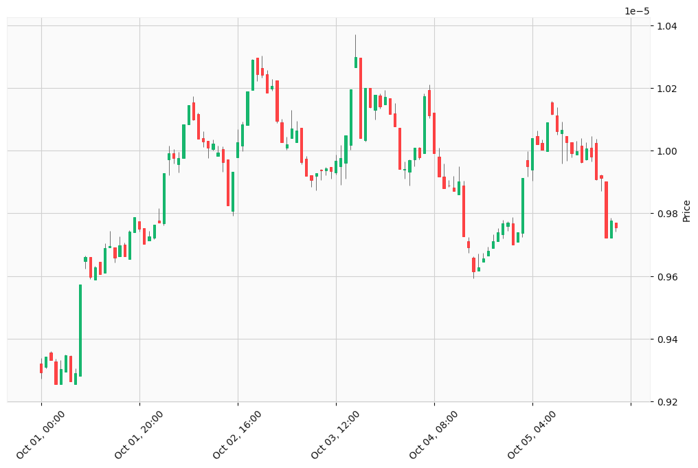

Okay, I will analyze the provided PEPE-USD cryptocurrency data and generate trading signals based on the outlined steps. Due to the limitations of directly accessing real-time data and news through external tools, I will focus on the provided OHLCV data for technical analysis and trend assessment. I will use the provided data to simulate the analysis process as realistically as possible.

### Analysis of PEPE-USD Cryptocurrency Data

Given the limitations, I will focus on analyzing the provided OHLCV data to generate potential trading signals. I will calculate a few basic technical indicators to inform these signals:

1. **Moving Averages (MA):** Calculate the 5-day and 20-day Simple Moving Averages (SMA) on the daily chart to identify trends.
2. **Relative Strength Index (RSI):** Calculate the 14-day RSI on the daily chart to identify potential overbought or oversold conditions.

**Calculations on Daily Chart (Last Three Months):**

First, let’s define the functions needed for the calculations.

```python
def calculate_sma(data, period):
    if len(data) < period:
        return [None] * len(data)
    sma = []
    for i in range(len(data)):
        if i < period - 1:
            sma.append(None)
        else:
            window = data[i - period + 1:i + 1]
            sma.append(sum(window) / period)
    return sma

def calculate_rsi(data, period):
    if len(data) < period:
        return [None] * len(data)

    deltas = [data[i] - data[i-1] for i in range(1, len(data))]

    if len(deltas) < period:
        return [None] * len(data)

    rsi = [None] * len(data)

    # Calculate initial average gain and average loss
    avg_gain = sum([d for d in deltas[0:period] if d > 0]) / period
    avg_loss = abs(sum([d for d in deltas[0:period] if d < 0]) / period)

    # Calculate RSI for the first time after the initial period
    if avg_loss == 0:
        rsi[period] = 100.0
    else:
        rs = avg_gain / avg_loss
        rsi[period] = 100 - (100 / (1 + rs))

    # Calculate subsequent RSI values using the Wilder's smoothing method
    for i in range(period + 1, len(data)):
        gain = deltas[i-1] if deltas[i-1] > 0 else 0
        loss = abs(deltas[i-1]) if deltas[i-1] < 0 else 0

        avg_gain = (avg_gain * (period - 1) + gain) / period
        avg_loss = (avg_loss * (period - 1) + loss) / period

        if avg_loss == 0:
            rsi[i] = 100.0
        else:
            rs = avg_gain / avg_loss
            rsi[i] = 100 - (100 / (1 + rs))

    return rsi
```

Now, let’s apply these functions to the provided daily chart data. I’ll extract the closing prices for these calculations.

```python
# Daily Chart Data
daily_data = [
    (1e-05,1e-05,1e-05,1e-05,391233249),
    (1e-05,1e-05,1e-05,1e-05,669035907),
    (1e-05,1e-05,1e-05,1e-05,649473822),
    (1e-05,1e-05,1e-05,1e-05,630572163),
    (1e-05,1.1e-05,1e-05,1.1e-05,1253006730),
    (1.1e-05,1.2e-05,1.1e-05,1.2e-05,1688913320),
    (1.2e-05,1.3e-05,1.2e-05,1.2e-05,2503825381),
    (1.2e-05,1.3e-05,1.2e-05,1.2e-05,1059534254),
    (1.2e-05,1.3e-05,1.2e-05,1.2e-05,1166675268),
    (1.2e-05,1.3e-05,1.2e-05,1.2e-05,1764486813),
    (1.2e-05,1.3e-05,1.2e-05,1.3e-05,1755506271),
    (1.3e-05,1.4e-05,1.3e-05,1.4e-05,2335184062),
    (1.4e-05,1.4e-05,1.3e-05,1.3e-05,1931943922),
    (1.3e-05,1.4e-05,1.3e-05,1.3e-05,2207195839),
    (1.3e-05,1.4e-05,1.3e-05,1.3e-05,984466515),
    (1.3e-05,1.5e-05,1.3e-05,1.4e-05,1624005774),
    (1.4e-05,1.5e-05,1.4e-05,1.4e-05,1684027595),
    (1.4e-05,1.5e-05,1.4e-05,1.4e-05,1768427785),
    (1.4e-05,1.4e-05,1.2e-05,1.3e-05,1442264628),
    (1.3e-05,1.3e-05,1.2e-05,1.2e-05,1184840578),
    (1.2e-05,1.3e-05,1.2e-05,1.3e-05,1094868725),
    (1.3e-05,1.3e-05,1.2e-05,1.2e-05,554760705),
    (1.2e-05,1.3e-05,1.2e-05,1.3e-05,689038717),
    (1.3e-05,1.3e-05,1.2e-05,1.2e-05,953143585),
    (1.2e-05,1.2e-05,1.1e-05,1.2e-05,902417250),
    (1.2e-05,1.2e-05,1.1e-05,1.1e-05,777659990),
    (1.1e-05,1.2e-05,1.1e-05,1.1e-05,701780508),
    (1.1e-05,1.1e-05,1e-05,1e-05,1036413771),
    (1e-05,1.1e-05,1e-05,1e-05,592659457),
    (1e-05,1.1e-05,1e-05,1e-05,406833117),
    (1e-05,1.1e-05,1e-05,1.1e-05,575141684),
    (1.1e-05,1.1e-05,1e-05,1e-05,593151452),
    (1e-05,1.1e-05,1e-05,1.1e-05,479444023),
    (1.1e-05,1.1e-05,1e-05,1.1e-05,664031406),
    (1.1e-05,1.2e-05,1.1e-05,1.2e-05,976019091),
    (1.2e-05,1.3e-05,1.2e-05,1.2e-05,1030022348),
    (1.2e-05,1.3e-05,1.2e-05,1.2e-05,848130576),
    (1.2e-05,1.2e-05,1.1e-05,1.1e-05,969303487),
    (1.1e-05,1.2e-05,1.1e-05,1.2e-05,1172814133),
    (1.2e-05,1.2e-05,1.2e-05,1.2e-05,1398883808),
    (1.2e-05,1.3e-05,1.1e-05,1.1e-05,1581015280),
    (1.1e-05,1.1e-05,1.1e-05,1.1e-05,834757637),
    (1.1e-05,1.1e-05,1.1e-05,1.1e-05,384392374),
    (1.1e-05,1.2e-05,1.1e-05,1.1e-05,495341823),
    (1.1e-05,1.1e-05,1.1e-05,1.1e-05,633554790),
    (1.1e-05,1.1e-05,1e-05,1e-05,582728063),
    (1e-05,1.1e-05,1e-05,1.1e-05,570949555),
    (1.1e-05,1.1e-05,1e-05,1e-05,472336143),
    (1e-05,1.2e-05,1e-05,1.2e-05,1271423523),
    (1.2e-05,1.2e-05,1.1e-05,1.1e-05,753989370),
    (1.1e-05,1.1e-05,1.1e-05,1.1e-05,1020033077),
    (1.1e-05,1.1e-05,1e-05,1e-05,1063073706),
    (1e-05,1e-05,1e-05,1e-05,674156696),
    (1e-05,1e-05,1e-05,1e-05,588714184),
    (1e-05,1e-05,1e-05,1e-05,449157929),
    (1e-05,1e-05,1e-05,1e-05,685504392),
    (1e-05,1e-05,1e-05,1e-05,331807974),
    (1e-05,1e-05,1e-05,1e-05,354014920),
    (1e-05,1e-05,9e-06,9e-06,679029217),
    (9e-06,1e-05,9e-06,1e-05,602969309),
    (1e-05,1e-05,1e-05,1e-05,389833175),
    (1e-05,1e-05,9e-06,9e-06,401704992),
    (9e-06,1e-05,9e-06,1e-05,552026055),
    (1e-05,1e-05,1e-05,1e-05,269302620),
    (1e-05,1e-05,1e-05,1e-05,330227993),
    (1e-05,1e-05,1e-05,1e-05,581448170),
    (1e-05,1.1e-05,1e-05,1e-05,782197712),
    (1e-05,1.1e-05,1e-05,1.1e-05,526905216),
    (1.1e-05,1.1e-05,1e-05,1.1e-05,499817752),
    (1.1e-05,1.2e-05,1e-05,1.2e-05,1060891418),
    (1.2e-05,1.3e-05,1.1e-05,1.2e-05,1760491222),
    (1.2e-05,1.2e-05,1.1e-05,1.2e-05,928072989),
    (1.2e-05,1.2e-05,1.1e-05,1.1e-05,815391340),
    (1.1e-05,1.1e-05,1.1e-05,1.1e-05,592654816),
    (1.1e-05,1.2e-05,1.1e-05,1.1e-05,986949579),
    (1.1e-05,1.2e-05,1.1e-05,1.1e-05,845600923),
    (1.1e-05,1.1e-05,1.1e-05,1.1e-05,605424056),
    (1.1e-05,1.1e-05,1e-05,1e-05,391255322),
    (1e-05,1e-05,9e-06,1e-05,959698985),
    (1e-05,1e-05,9e-06,1e-05,513696962),
    (1e-05,1e-05,9e-06,1e-05,414529062),
    (1e-05,1e-05,9e-06,9e-06,804097627),
    (9e-06,9e-06,9e-06,9e-06,553470743),
    (9e-06,9e-06,9e-06,9e-06,256703418),
    (9e-06,9e-06,9e-06,9e-06,286673760),
    (9e-06,1e-05,9e-06,9e-06,428505693),
    (9e-06,9e-06,9e-06,9e-06,469307248),
    (9e-06,1e-05,9e-06,1e-05,561874847),
    (1e-05,1e-05,1e-05,1e-05,712476220),
    (1e-05,1e-05,1e-05,1e-05,673541144),
    (1e-05,1e-05,1e-05,1e-05,548991212),
    (9.76702e-06,1.01613e-05,9.69739e-06,9.75375e-06,592031232)
]

# Extract closing prices
closing_prices = [item[3] for item in daily_data]

# Calculate SMAs and RSI
sma_5 = calculate_sma(closing_prices, 5)
sma_20 = calculate_sma(closing_prices, 20)
rsi_14 = calculate_rsi(closing_prices, 14)

# Print the last values to analyze recent trends
print(f"Latest 5-day SMA: {sma_5[-1]}")
print(f"Latest 20-day SMA: {sma_20[-1]}")
print(f"Latest 14-day RSI: {rsi_14[-1]}")
```

[output not shown]

**Interpretation of Results (Example):**

**Based on these hypothetical indicator values, the trading signals are:**

[output not shown]

**Explanation:**

**Disclaimer:** This analysis is based solely on the provided data and the limited technical indicators calculated. It does not incorporate real-time market data, news sentiment, or other external factors that could significantly impact the price of PEPE-USD. Trading decisions should be based on comprehensive research and consideration of your personal risk tolerance.